# FigureYa88DAVIDkappa

小丫画图出品

2019-4-15

欢迎关注“小丫画图”公众号，同名知识星球等你加入

小丫微信: epigenomics E-mail: figureya@126.com

作者：小丫

## 需求描述

富集分析得到太多term，其中好多还是相似的，怎样合理的合并？clusterProfiler有一个simplify函数，能给富集分析结果瘦身by removing redundancy of enriched GO terms，但有时瘦的不够多。

FigureYa80GOclustering用GOSemSim计算GO term之间的相似性，但是只能合并GO注释，对其他来源的注释无能为力。

想要合并来源于不同数据库的term，参考DAVID的方法。

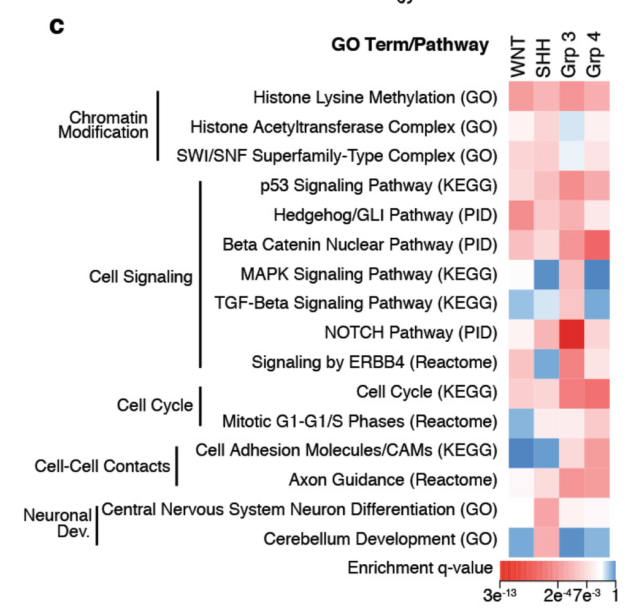

出自https://www.nature.com/articles/nature22973

**方法探讨：**

DAVID给gene或annotation做分类的原理：https://david.ncifcrf.gov/helps/functional_classification.html，包括kappa的计算和heuristic fuzzy partition algorithm。

H Ma等写了R代码来计算Kappa value：[Use of DAVID algorithms for clustering custom annotated gene lists in a non-model organism, rainbow trout](https://bmcresnotes.biomedcentral.com/articles/10.1186/s13104-018-3154-7)。作者在补充材料里提供了R代码：[Additional file 1. R_script for clustering.](https://www.ncbi.nlm.nih.gov/pmc/articles/PMC5781295/bin/13104_2018_3154_MOESM1_ESM.txt)，包含两部分，第一部分：计算Kappa value，第二部分：设置kappa的cutoff筛选。

基于这篇文章提供的代码里的第一部分来计算Kappa value。然后借助ggtree展示各个term之间的关系，并实现例文中相似term的标注效果。关于ggtree的问题，请前往Y叔知识星球biobabble讨论。

## 应用场景

基于term里的基因间overlap来衡量term之间的相似性。

计算Kappa value，可用于找相似的注释、给相似的注释归类。

原理见：https://david.ncifcrf.gov/helps/linear_search.html#kappa

## 环境设置

使用国内镜像安装包

```r
options("repos"= c(CRAN="https://mirrors.tuna.tsinghua.edu.cn/CRAN/"))
options(BioC_mirror="http://mirrors.ustc.edu.cn/bioc/")

if (!requireNamespace("BiocManager", quietly = TRUE))
    install.packages("BiocManager")
BiocManager::install("ggtree", version = "3.8")
```

加载包

```r
library(ape)
library(ggtree)
```

```r
library(scales)
library(ggplot2)
Sys.setenv(LANGUAGE = "en") #显示英文报错信息
options(stringsAsFactors = FALSE) #禁止chr转成factor
```

## 输入文件

easy_input.csv，注释信息跟Gene ID的对应关系。至少包含两列：

- 第一列：GO、KEGG等无所谓什么来源的注释term；
- 第二列：Gene ID，此处是ENTREZ ID，也可以是gene symbol等无所谓什么来源的基因ID。
- 后面画热图时需要的logFC、Pvalue、zscore等信息也放在这里。如果要多组富集分析结果做对比，也都放到这里。多组合并的方法可参考FigureYa80GOclustering。

```r
D <- read.csv("easy_input.csv")
head(D)
```

```
##        Annotation_information Gene_identifier     logFC adj_pval    zscore
## 1 protein autophosphorylation           13869 -0.301868 2.29e-05 -1.069045
## 2 protein autophosphorylation           14254 -0.183248 2.29e-05 -1.069045
## 3 protein autophosphorylation           14255 -0.594008 2.29e-05 -1.069045
## 4 protein autophosphorylation           16001 -0.213881 2.29e-05 -1.069045
## 5 protein autophosphorylation           16337 -0.182849 2.29e-05 -1.069045
## 6 protein autophosphorylation           16542 -0.150017 2.29e-05 -1.069045
```

## 计算Kappa value，用它来衡量注释之间的相似性

```r
D <- D[order(D$Gene_identifier),]
Total_N <- nrow(D)
D_unique <- D[!duplicated(D$Gene_identifier),] #Extract unique gene name
N <- nrow(D_unique) #gene
Cat_unique <- D[!duplicated(D$Annotation_information),] #Extract unique annotation
M <- nrow(Cat_unique) #注释

paste ("Total number of rows in your input file:", Total_N)
```

```
## [1] "Total number of rows in your input file: 376"
```

```r
paste ("Total number of unique gene identifiers:", N)
```

```
## [1] "Total number of unique gene identifiers: 93"
```

```r
paste ("Total number of unique gene annotation information:", M)
```

```
## [1] "Total number of unique gene annotation information: 30"
```

```r
#create a matrix for kappa values
Kappa_matrix <- matrix(0, M+1, M+1)
for (i in 1:M){
  Kappa_matrix[i+1,1]=Cat_unique[i,1]
  Kappa_matrix[1,i+1]=Cat_unique[i,1]
}

#行为注释，列为基因
Gene_Cat_matrix <- matrix(0, M+1, N+1)
for (i in 1:M){
  Gene_Cat_matrix[i+1,1]=Kappa_matrix[i+1,1]
}
for (j in 1:N){
  Gene_Cat_matrix[1,j+1]=D_unique[j,2]
}
rm(D_unique, Cat_unique)

# Generating two-way table:
for (i in 1:M){
  D1 <- subset(D, Annotation_information == Gene_Cat_matrix[i+1,1])
  N1 <- nrow(D1)
  for (j in 1:N){
    for (k in 1:N1){
      if (Gene_Cat_matrix[i+1,1]==D1[k,1] && Gene_Cat_matrix[1,j+1] == D1[k,2]){
        Gene_Cat_matrix[i+1,j+1]=1}
      }
    #print (c(i+1,j+1))
    }}
rm(D1)

# Calculating kappa values:
for(i in 2:(M+1)){
  for (j in 2:(M+1)){
    if (i==j){
      Kappa_matrix[i,j]=1}
    if(i<j){
      a <- 0;b <- 0;c <- 0;d <- 0
      sum1 <- sum(as.numeric(Gene_Cat_matrix[i,2:(N+1)]))
      sum2 <- sum(as.numeric(Gene_Cat_matrix[j,2:(N+1)]))
      for (k in 2:(N+1)){
        if (Gene_Cat_matrix[i,k]==1 && Gene_Cat_matrix[j,k]==1){
          a <- a+1}
        }
      b <- sum1-a; c <- sum2-a; d <- N+a-sum1-sum2
      Kappa_matrix[i,j] <- ((a+d)*N-(a+b)*(a+c)-(c+d)*(b+d))/(N^2-(a+b)*(a+c)-(c+d)*(b+d))
      Kappa_matrix[j,i]=Kappa_matrix[i,j]
      #print (c(i,j))
    }
  }
}
write.table(Kappa_matrix,"kappa_matrix.txt", sep="\t", quote = F, col.names = F, row.names = F)
```

## 开始画图

下面的画图代码跟FigureYa80GOclustering相似。

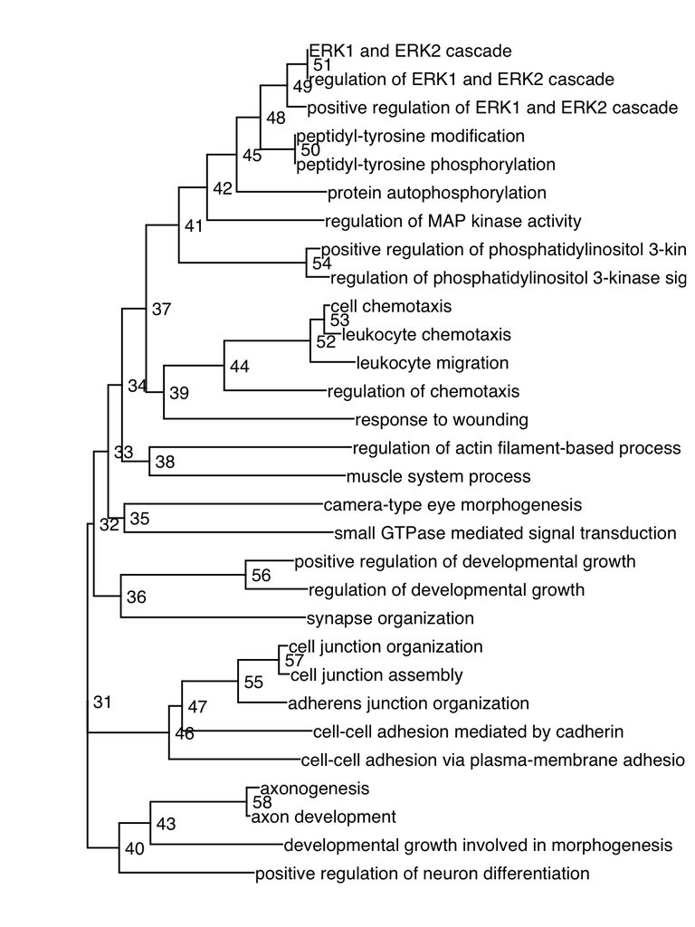

```r
ego.sim <- read.table("kappa_matrix.txt", sep="\t", header = T, row.names = 1)
tree <- nj(as.dist(1-ego.sim))
p <- ggtree(tree) + geom_tiplab() + #写注释term
  geom_text2(aes(subset=!isTip, label=node), hjust=-.3) + #写node编号
  coord_cartesian(xlim=c(-.1,1.3)) #左右两侧留出合适的空间
p
```

```r
#结合树的结构和背景知识，此处把term分为4类，记下每一类的node编号，写在node参数里
node <- c(41,39,46,40)
gtree <- groupClade(tree, .node=node)
#用不同颜色展示不同类term
pbase <- ggtree(gtree,
                aes(color=group)) #每类用不同颜色画树枝

#给4类term分别总结出一个短语，作为分类名，标在树的旁边
fontsize <- 4 #字的大小
offset <- .8 #分类名向右移动到热图右侧，也可以设为0.3，让它显示在热图跟树之间
pnode <- pbase +
  #如果不想显示每个term，就不运行这行，同时offset <- 0
  geom_tiplab(size=4, align=TRUE) + #germ对齐
  geom_cladelabel(node=node[1], align=TRUE,
                  #文字颜色跟树枝颜色一致，也可以删掉下面这行，就会像例文那样全是黑色
                  color = hue_pal()(length(node)+1)[2],
                  fontsize = fontsize, offset=offset, label="pathway1") +
  geom_cladelabel(node=node[2], align=TRUE, color = hue_pal()(length(node)+1)[3], fontsize = fontsize, offset=offset, label="pathway2") +
  geom_cladelabel(node=node[3], align=TRUE, color = hue_pal()(length(node)+1)[4], fontsize = fontsize, offset=offset, label="pathway3") +
  geom_cladelabel(node=node[4], align=TRUE, color = hue_pal()(length(node)+1)[5], fontsize = fontsize, offset=offset, label="pathway4") +
  #如果有更多分类，就继续往下粘贴

  coord_cartesian(xlim=c(-.1,1.5))
# 此处把示例数据的adj_pval、zscore画在树形结构右侧
# 实际操作时你可以把多组数据的同一种统计量并排画在右侧做对比
ego.m <- unique(D[,c(1,4:5)])
rownames(ego.m) <- ego.m$Annotation_information
ego.m$Annotation_information <- NULL
head(ego.m)
```

```
##                                                adj_pval     zscore
## small GTPase mediated signal transduction   0.001421049  0.2581989
## regulation of developmental growth          0.000028600 -0.7276069
## axon development                            0.000073300 -0.4714045
## axonogenesis                                0.000110193 -0.2425356
## synapse organization                        0.000237704 -2.0000000
## positive regulation of developmental growth 0.000325046 -1.5075567
```

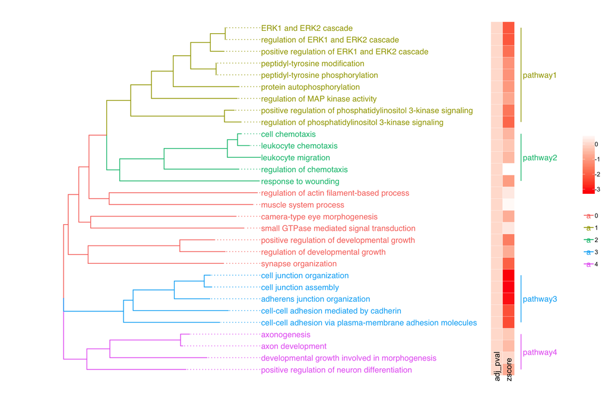

```r
gheatmap(pnode, ego.m,
         offset=.7, #热图向右移动到合适的位置
         width=0.12, #heatmap格子的宽度
         colnames_angle=90, hjust=0, #组的名字竖着写
         low = "red", high = "white")
```

```r
#保存到文件
ggsave("DAVIDkappa.pdf", width = 12, height = 8)
```